# Multivariable Regression

David Asare Kumi

June 22, 2019

## Multivariable Regression

- This is an extension of linear regression where more independent variables are added to the model.
- The general linear model extends simple linear regression (SLR) by adding terms linearly into the model.

## How to get estimates

### Example

```r
n<-100
x<-rnorm(n)
x2<-rnorm(n)
x3<-rnorm(n)
y<-1+x+x2+x3+rnorm(n,sd=0.1) #mean=0 (origin)
ey<-resid(lm(y~x2+x3))
ex<-resid(lm(x~x2+x3))
#regression to the origin
sum(ey*ex)/sum(ex^2)
```

```
[1] 1.008622
```

```r
coef(lm(y~x+x2+x3))
```

```
(Intercept)           x          x2          x3
  0.9969693   1.0086224   1.0079331   0.9940472
```

```r
#alternatively
coef(lm(ey~ex-1)) # take out the intercept
```

```
      ex
1.008622
```

## Interpretation of the coefficients

- The interpretation of a multivariable regression coefficient is the expected change in the response variable per unit change in the regressor variable holding all of the other regressors fixed(constant).

## Multivariable Regression tips and tricks

### Example (part1)

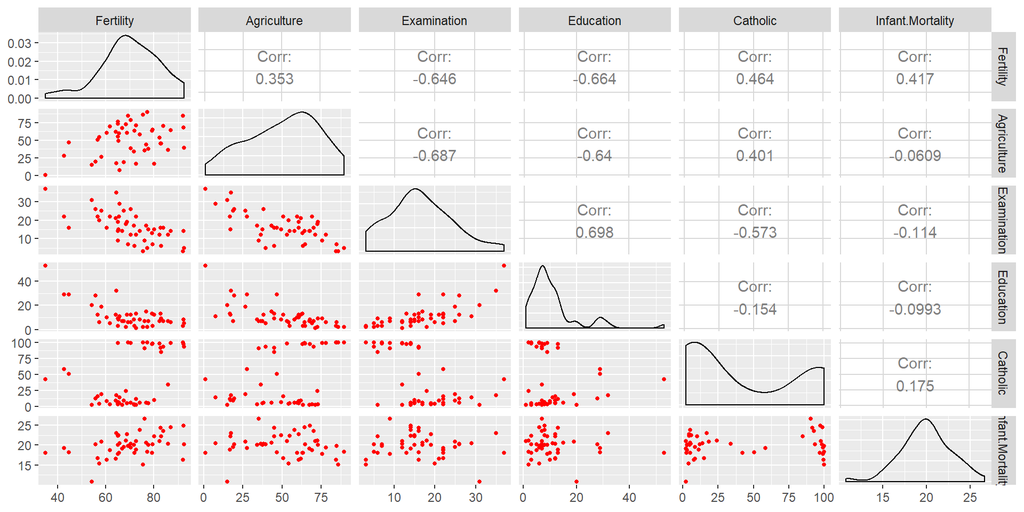

```r
library(datasets)
data(swiss)
library(ggplot2)
library(GGally)
g <-ggpairs(swiss,1:6,lower=list(continuous=wrap(ggally_points,size=1,color="red")))
g
```

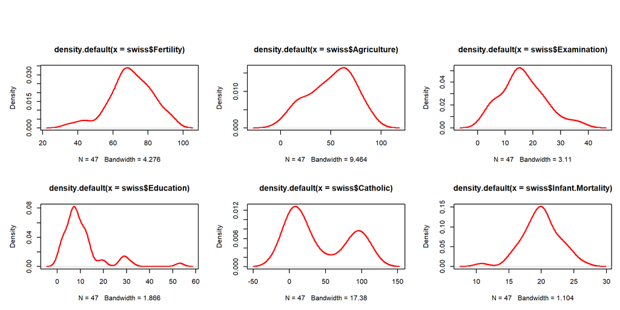

```r
#The GGally package gives you the scatterplot,density plots and the correlations of the variables.

#Plot densities of the variables
par(mfrow=c(2,3),mar=c(5,5,4,1),oma=c(0,0,4,0))
plot(density(swiss$Fertility),col="red",lty=1,lwd=2)
plot(density(swiss$Agriculture),col="red",lty=1,lwd=2)
plot(density(swiss$Examination),col="red",lty=1,lwd=2)
plot(density(swiss$Education),col="red",lty=1,lwd=2)
plot(density(swiss$Catholic),col="red",lty=1,lwd=2)
plot(density(swiss$Infant.Mortality),col="red",lty=1,lwd=2)
```

```r
#Calculation of correlations
cor(swiss)
```

```
                  Fertility Agriculture Examination   Education   Catholic
Fertility         1.0000000  0.35307918  -0.6458827 -0.66378886  0.4636847
Agriculture       0.3530792  1.00000000  -0.6865422 -0.63952252  0.4010951
Examination      -0.6458827 -0.68654221   1.0000000  0.69841530 -0.5727418
Education        -0.6637889 -0.63952252   0.6984153  1.00000000 -0.1538589
Catholic          0.4636847  0.40109505  -0.5727418 -0.15385892  1.0000000
Infant.Mortality  0.4165560 -0.06085861  -0.1140216 -0.09932185  0.1754959
                 Infant.Mortality
Fertility              0.41655603
Agriculture           -0.06085861
Examination           -0.11402160
Education             -0.09932185
Catholic               0.17549591
Infant.Mortality       1.00000000
```

## Multiple Regression Coefficients

```r
library(datasets)
data(swiss)
library(ggplot2)
fit <-lm(Fertility~.,data=swiss)
#Various ways to derive regression coefficients
fit
```

```
Call:
lm(formula = Fertility ~ ., data = swiss)

Coefficients:
     (Intercept)       Agriculture       Examination         Education
         66.9152           -0.1721           -0.2580           -0.8709
        Catholic  Infant.Mortality
          0.1041            1.0770
```

```r
coef(fit)
```

```
     (Intercept)      Agriculture      Examination        Education
      66.9151817       -0.1721140       -0.2580082       -0.8709401
        Catholic Infant.Mortality
       0.1041153        1.0770481
```

```r
summary(fit)$coef
```

```
                   Estimate  Std. Error   t value     Pr(>|t|)
(Intercept)      66.9151817 10.70603759  6.250229 1.906051e-07
Agriculture      -0.1721140  0.07030392 -2.448142 1.872715e-02
Examination      -0.2580082  0.25387820 -1.016268 3.154617e-01
Education        -0.8709401  0.18302860 -4.758492 2.430605e-05
Catholic          0.1041153  0.03525785  2.952969 5.190079e-03
Infant.Mortality  1.0770481  0.38171965  2.821568 7.335715e-03
```

```r
summary(fit)
```

```
Call:
lm(formula = Fertility ~ ., data = swiss)

Residuals:
     Min       1Q   Median       3Q      Max
-15.2743  -5.2617   0.5032   4.1198  15.3213

Coefficients:
                 Estimate Std. Error t value Pr(>|t|)
(Intercept)      66.91518   10.70604   6.250 1.91e-07 ***
Agriculture      -0.17211    0.07030  -2.448  0.01873 *
Examination      -0.25801    0.25388  -1.016  0.31546
Education        -0.87094    0.18303  -4.758 2.43e-05 ***
Catholic          0.10412    0.03526   2.953  0.00519 **
Infant.Mortality  1.07705    0.38172   2.822  0.00734 **
---
Signif. codes:  0 '***' 0.001 '**' 0.01 '*' 0.05 '.' 0.1 ' ' 1

Residual standard error: 7.165 on 41 degrees of freedom
Multiple R-squared:  0.7067,    Adjusted R-squared:  0.671
F-statistic: 19.76 on 5 and 41 DF,  p-value: 5.594e-10
```

## Model Selection

```r
library(datasets)
data(swiss)
library(ggplot2)
fit <-lm(Fertility~Agriculture,data=swiss)
summary(fit)$coef
```

```
              Estimate Std. Error   t value     Pr(>|t|)
(Intercept) 60.3043752 4.25125562 14.185074 3.216304e-18
Agriculture  0.1942017 0.07671176  2.531577 1.491720e-02
```

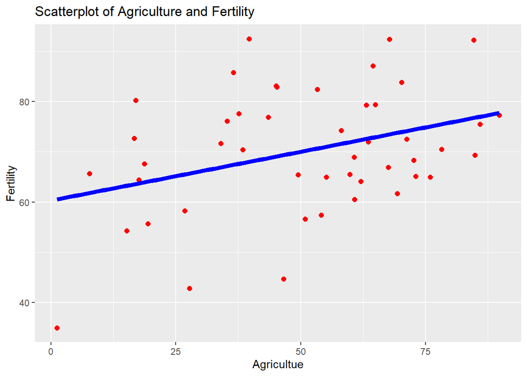

```r
#Scatterplot
g <-ggplot(swiss,aes(x=Agriculture,y=Fertility))+geom_point(size=2,color="red",alpha=1)
g <-g+geom_smooth(method="lm",color="blue",size=2,se=FALSE)
g <-g+labs(x="Agricultue",y="Fertility")+labs(title="Scatterplot of Agriculture and Fertility")
g
```

- The agriculture variable has a positive coefficient now (i.e. 0.1942). It is important to note that adjusting for the other variables changes the actual direction of the effect of agriculture on fertility. This is called Simpson’s paradox (Simpson’s perceived paradox).
- The sign reverses itself with the inclusion of Examination and Education.
- The percent of males in the province working in Agriculture is negatively related to educational attainment (correlation of -0.6395) and Education and Examination (correlation of 0.6984) are obviously measuring similar things.
- At the minimum, everyone claiming that provinces that are more agriculture inclined have higher fertility rates would immediately be open to criticisms.
- If Z=swiss$Agriculture + swiss$Education, then lm(Fertility~.+Z,data=swiss) has no added value because we already have the variables in the model. The Z variable created is assigned NA (totally unnecessary). Z is numerically related to other variables in the model already that is why it was assigned NA.

## Multivariable Regression

### Example part II (Factor Variables)

```r
require(datasets)
require(stats)
require(ggplot2)
data(InsectSprays)
dim(InsectSprays)
```

```
[1] 72  2
```

```r
str(InsectSprays)
```

```
'data.frame':   72 obs. of  2 variables:
 $ count: num  10 7 20 14 14 12 10 23 17 20 ...
 $ spray: Factor w/ 6 levels "A","B","C","D",..: 1 1 1 1 1 1 1 1 1 1 ...
```

```r
summary(InsectSprays)
```

```
     count       spray
 Min.   : 0.00   A:12
 1st Qu.: 3.00   B:12
 Median : 7.00   C:12
 Mean   : 9.50   D:12
 3rd Qu.:14.25   E:12
 Max.   :26.00   F:12
```

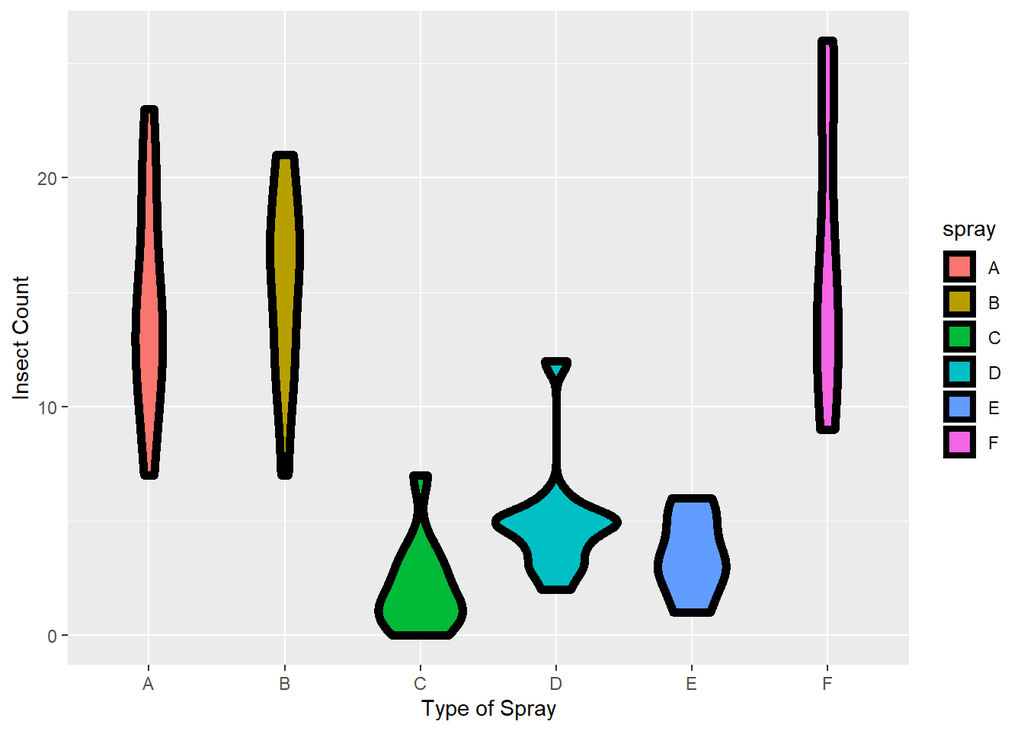

```r
g <-ggplot(data=InsectSprays,aes(y=count,x=spray,fill=spray))
g <-g + geom_violin(color="black",size=2)
g <-g + xlab("Type of Spray") + ylab("Insect Count")
g
```

```r
#Fit a model
fit <-lm(count~spray,data=InsectSprays)
summary(fit)$coef
```

```
               Estimate Std. Error    t value     Pr(>|t|)
(Intercept)  14.5000000   1.132156 12.8074279 1.470512e-19
sprayB        0.8333333   1.601110  0.5204724 6.044761e-01
sprayC      -12.4166667   1.601110 -7.7550382 7.266893e-11
sprayD       -9.5833333   1.601110 -5.9854322 9.816910e-08
sprayE      -11.0000000   1.601110 -6.8702352 2.753922e-09
sprayF        2.1666667   1.601110  1.3532281 1.805998e-01
```

- Spray A is missing - this means that everything here is in comparison with spray A. 0.833 is the change in the mean between spray B and spray A.
- The intercept 14.5 is the mean for spray A.
- The mean for spray B is 14.5 + 0.833 = 15.333.
- The mean for spray C is 14.5 - 12.417 = 2.083.
- The mean for spray D is 14.5 - 9.58 = 4.92.
- The mean for spray E is 14.5 - 11.0 = 3.50.
- The mean for spray F is 14.5 + 2.17 = 16.67.
- Compare spray B and C ; 0.833 - (-12.417) = 0.833 + 12.417 = 13.250.

## Hard coding the dummy variable

- Here we do not allow R to do the reference.

```r
require(datasets)
require(stats)
require(ggplot2)
data(InsectSprays)
dim(InsectSprays)
```

```
[1] 72  2
```

```r
fit <-lm(count~I(1*(spray=="B"))+I(1*(spray=="C"))+I(1*(spray=="D"))+I(1*(spray=="E"))+I(1*(spray=="F")),data=InsectSprays)
summary(fit)$coef
```

```
                         Estimate Std. Error    t value     Pr(>|t|)
(Intercept)            14.5000000   1.132156 12.8074279 1.470512e-19
I(1 * (spray == "B"))   0.8333333   1.601110  0.5204724 6.044761e-01
I(1 * (spray == "C")) -12.4166667   1.601110 -7.7550382 7.266893e-11
I(1 * (spray == "D"))  -9.5833333   1.601110 -5.9854322 9.816910e-08
I(1 * (spray == "E")) -11.0000000   1.601110 -6.8702352 2.753922e-09
I(1 * (spray == "F"))   2.1666667   1.601110  1.3532281 1.805998e-01
```

- lm(count~spray) ;This picks the lowest alphanumeric variable and sets it as a reference.
- The hard coding approach also sets spray A as the reference and the results is the same as the one obtained.
- What if we include all six(6) sprays i.e. spray A is added; when you include spray A, the lm model returns NA for spray A because it is redundant.

## What if you want the coefficients to be the mean for the group

- You can do this but you have to remove the intercept by subtracting 1.

```r
require(datasets)
require(stats)
require(ggplot2)
data(InsectSprays)
fit <-lm(count~spray-1,data=InsectSprays)
summary(fit)$coef
```

```
        Estimate Std. Error   t value     Pr(>|t|)
sprayA 14.500000   1.132156 12.807428 1.470512e-19
sprayB 15.333333   1.132156 13.543487 1.001994e-20
sprayC  2.083333   1.132156  1.840148 7.024334e-02
sprayD  4.916667   1.132156  4.342749 4.953047e-05
sprayE  3.500000   1.132156  3.091448 2.916794e-03
sprayF 16.666667   1.132156 14.721181 1.573471e-22
```

```r
#Calculate the means to cross check with the coefficients
library(dplyr)
summarise(group_by(InsectSprays,spray),mn=mean(count))
```

```
# A tibble: 6 x 2
  spray    mn
  <fct> <dbl>
1 A     14.5
2 B     15.3
3 C      2.08
4 D      4.92
5 E      3.5
6 F     16.7
```

```r
#This model is the same as the one with the intercept.
```

## Reordering the levels

```r
require(datasets)
require(stats)
require(ggplot2)
data(InsectSprays)
spray2 <-relevel(InsectSprays$spray,"C")
fit <-lm(count~spray2,data=InsectSprays)
summary(fit)$coef
```

```
             Estimate Std. Error  t value     Pr(>|t|)
(Intercept)  2.083333   1.132156 1.840148 7.024334e-02
spray2A     12.416667   1.601110 7.755038 7.266893e-11
spray2B     13.250000   1.601110 8.275511 8.509776e-12
spray2D      2.833333   1.601110 1.769606 8.141205e-02
spray2E      1.416667   1.601110 0.884803 3.794750e-01
spray2F     14.583333   1.601110 9.108266 2.794343e-13
```

```r
#The intercept is interpreted as the mean of the reference spray.
```

## Summary

- If we treat spray as a factor, R includes an intercept and omits the alphabetically first level of the factor.
- All t tests are for comparisons of Sprays versus Spray A.
- Empirical mean for A is the intercept.
- Other group means are the intercepts plus their coefficients.
- If we omit an intercept(itc) then it includes terms for all levels of Spray.
1. Group means are the coefficients.
2. Tests are tests of whether the groups are different than zero.
- If we want comparisons between Spray B and C, say relevel so that the B is the reference level.

## Multivariable Regression (Example Part III)

### Analysis of Covariates (ANCOVA)

```r
library(datasets)
library(dplyr)
library(ggplot2)
data(swiss)
names(swiss)
```

```
[1] "Fertility"        "Agriculture"      "Examination"
[4] "Education"        "Catholic"         "Infant.Mortality"
```

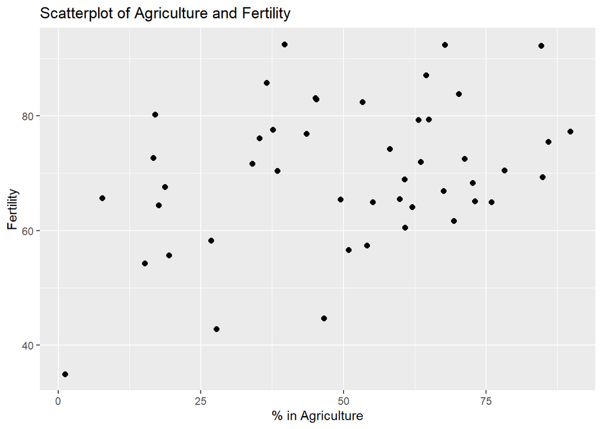

```r
#since its majority catholic let's use dplyr to create a factor variable (binary)
swiss <-mutate(swiss,CatholicBin=1*(Catholic >50))
#Plot the data
g <-ggplot(swiss,aes(x=Agriculture,y=Fertility))+ geom_point(size=2,color="black")
g <-g + labs(x="% in Agriculture",y="Fertility")+labs(title="Scatterplot of Agriculture and Fertility")
g
```

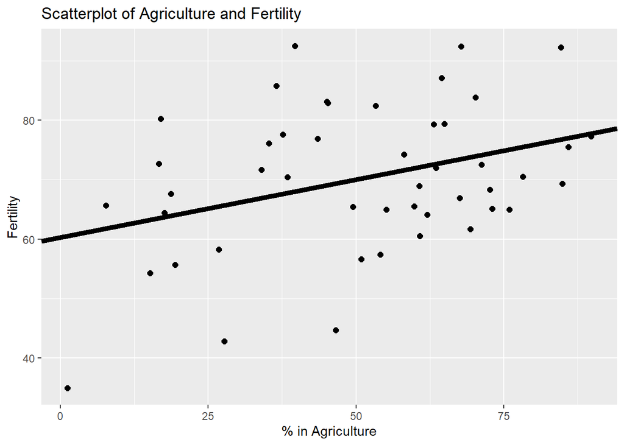

```r
#Fit model that does not include religion at all
fit <-lm(Fertility~Agriculture,data=swiss)
g1 <-g
g1 <-g1 + geom_abline(intercept=coef(fit)[1],slope=coef(fit)[2],size=2)
g1
```

```r
summary(fit)$coef
```

```
              Estimate Std. Error   t value     Pr(>|t|)
(Intercept) 60.3043752 4.25125562 14.185074 3.216304e-18
Agriculture  0.1942017 0.07671176  2.531577 1.491720e-02
```

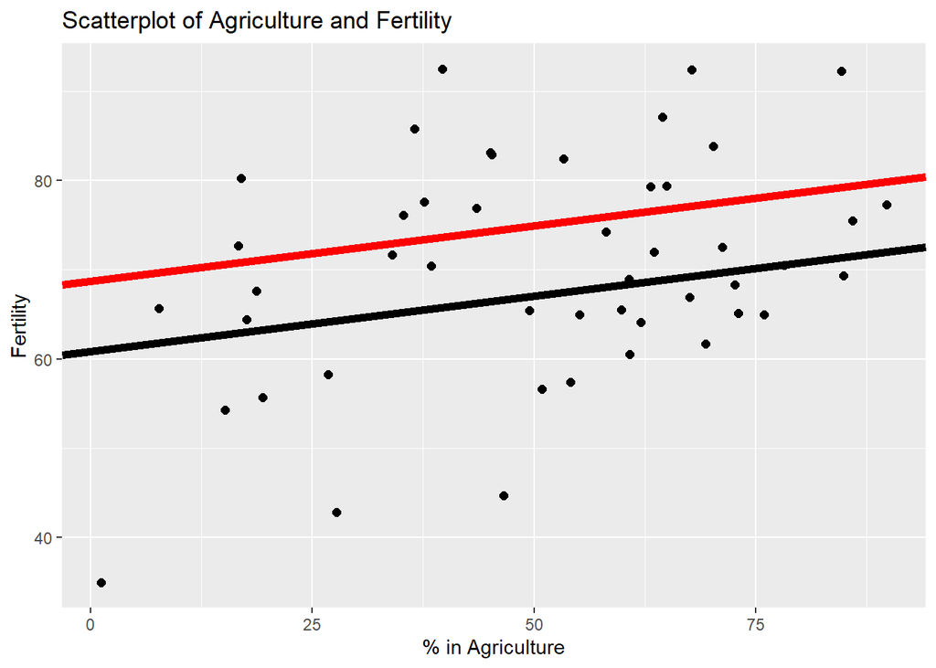

```r
#Let's fit two parallel lines
fit <-lm(Fertility~Agriculture+factor(CatholicBin),data=swiss)
g1 <-g
g1 <-g1 + geom_abline(intercept=coef(fit)[1],slope=coef(fit)[2],size=2)
g1 <-g1+geom_abline(intercept=coef(fit)[1]+coef(fit)[3],slope=coef(fit)[2],size=2,color="red")
g1
```

```r
summary(fit)$coef
```

```
                       Estimate Std. Error   t value     Pr(>|t|)
(Intercept)          60.8322366  4.1058630 14.815944 1.032493e-18
Agriculture           0.1241776  0.0810977  1.531210 1.328763e-01
factor(CatholicBin)1  7.8843292  3.7483622  2.103406 4.118221e-02
```

```r
#Lines where there are different intercepts and diffferent slopes
fit <-lm(Fertility~Agriculture*factor(CatholicBin),data=swiss)
summary(fit)$coef
```

```
                                    Estimate  Std. Error    t value
(Intercept)                      62.04993019  4.78915566 12.9563402
Agriculture                       0.09611572  0.09881204  0.9727127
factor(CatholicBin)1              2.85770359 10.62644275  0.2689238
Agriculture:factor(CatholicBin)1  0.08913512  0.17610660  0.5061430
                                     Pr(>|t|)
(Intercept)                      1.919379e-16
Agriculture                      3.361364e-01
factor(CatholicBin)1             7.892745e-01
Agriculture:factor(CatholicBin)1 6.153416e-01
```

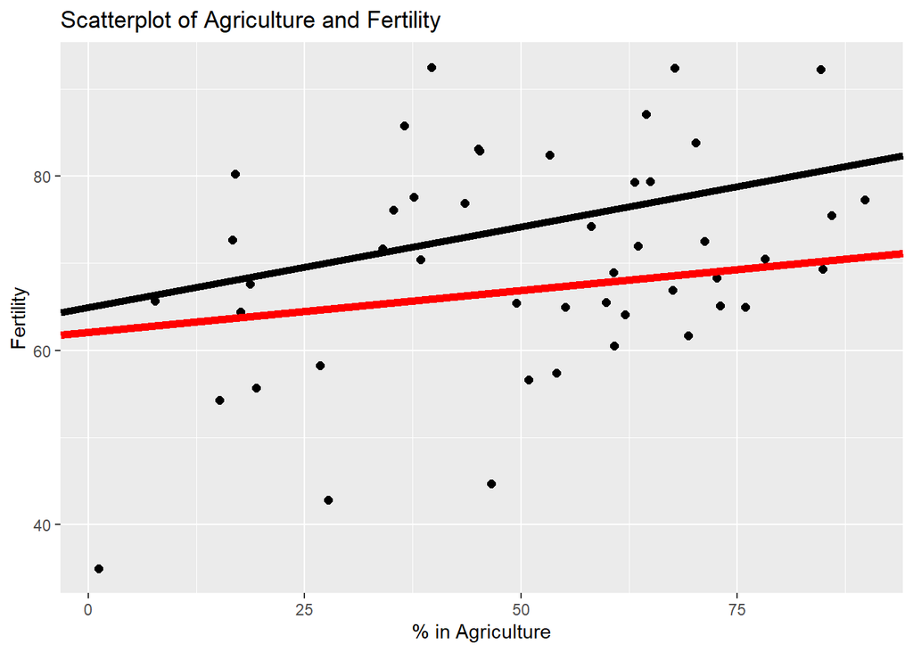

```r
#Now let's plot the two lines
g1 <-g
g1 <-g1 + geom_abline(intercept=coef(fit)[1],slope=coef(fit)[2],size=2,color="red")
g1 <-g1 + geom_abline(intercept=coef(fit)[1]+coef(fit)[3],slope=coef(fit)[2]+coef(fit)[4],size=2)
g1
```

## Adjustment

- Here we will use simulation to investigate how adding a regressor in to a model addresses the idea of adjustment.
- Things can change to exact opposite if you perform adjustment.

## Example

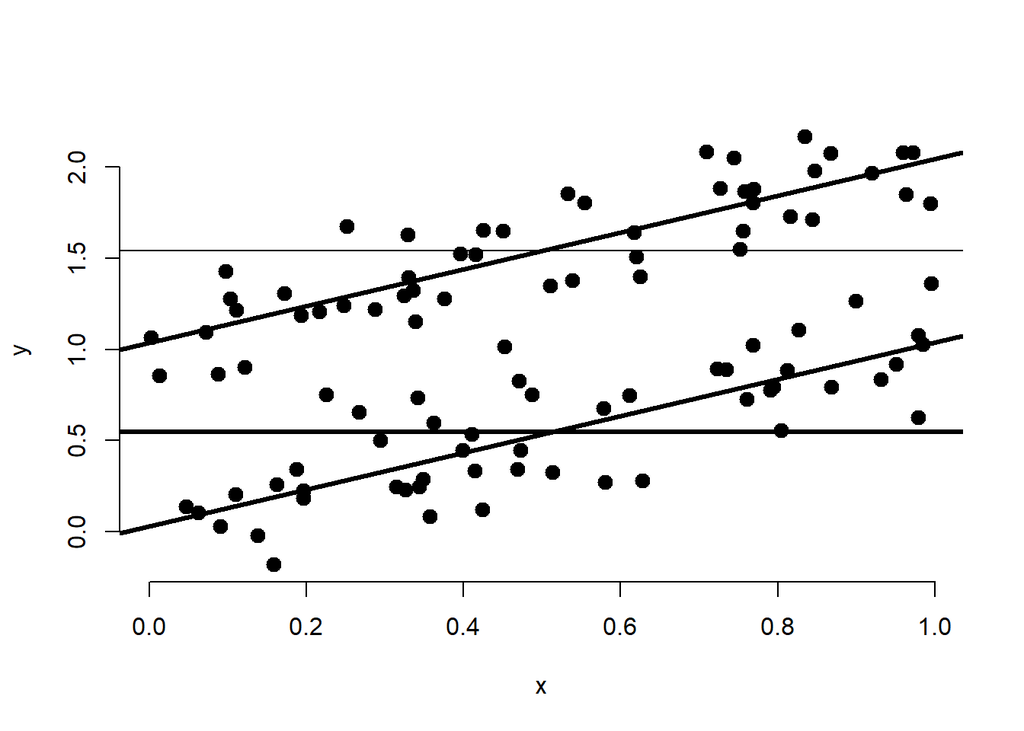

```r
n <-100
t <-rep(c(0,1),c(n/2,n/2))
x <-c(runif(n/2),runif(n/2))
beta0 <-0
beta1 <-1
tau <-1
sigma <-0.2
y <-beta0+x*beta1+t*tau+rnorm(n,sd=sigma)
plot(x,y,type="n",frame=FALSE)
abline(h=mean(y[1:(n/2)]),lwd=3)
abline(h=mean(y[(n/2+1):n],lwd=3))
fit <-lm(y~x+t)
abline(coef(fit)[1],coef(fit)[2],lwd=3)
abline(coef(fit)[1]+coef(fit)[3],coef(fit)[2],lwd=3)
points(x[1:(n/2)],y[1:(n/2)],pch=20,col="black",bg="lightblue",cex=2)
points(x[(n/2+1):n],y[(n/2+1):n],pch=20,col="black",bg="salmon",cex=2)
```

## Residuals Again

- The vertical distances between the observed data points and the fitted regression line are called residuals.We can generalize this idea to the vertical distances between the observed data and the fitted surface in multivariable settings.

## Residuals and Diagnostics (Part I)

```r
library(datasets)
library(ggplot2)
data(swiss)
par(mfrow=c(2,2),mar=c(4,4,2,1),oma=c(0,0,2,0))
fit <-lm(Fertility~.,data=swiss)
summary(fit)$coef
```

```
                   Estimate  Std. Error   t value     Pr(>|t|)
(Intercept)      66.9151817 10.70603759  6.250229 1.906051e-07
Agriculture      -0.1721140  0.07030392 -2.448142 1.872715e-02
Examination      -0.2580082  0.25387820 -1.016268 3.154617e-01
Education        -0.8709401  0.18302860 -4.758492 2.430605e-05
Catholic          0.1041153  0.03525785  2.952969 5.190079e-03
Infant.Mortality  1.0770481  0.38171965  2.821568 7.335715e-03
```

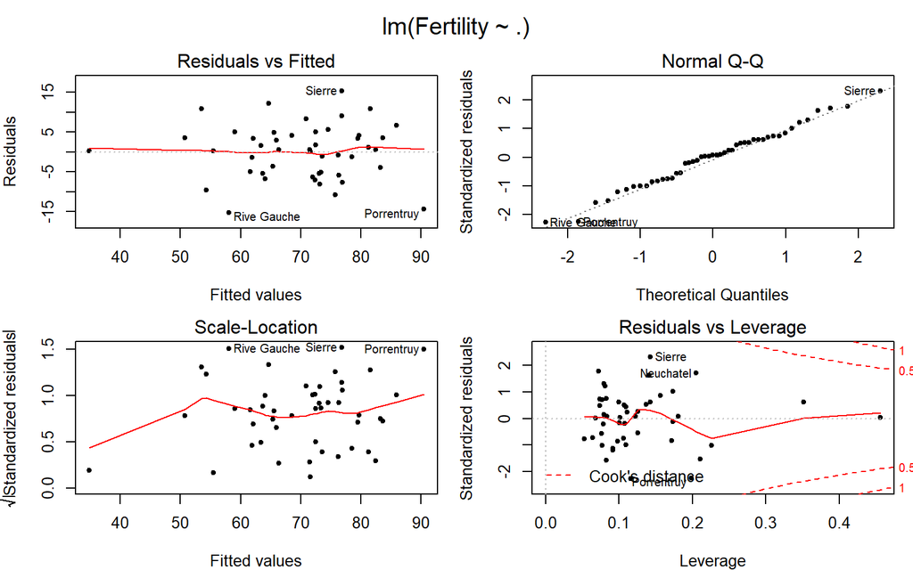

```r
plot(fit,cex=1,pch=20)
```

## Influencial high leverage and outlying points

- Leverag; How far away from the center of the axis the data point is.
- Influence: Whether or not that point chooses to exert that leverage.

## Residuals and Diagnostics (Part II)

### Summary of the plot

- Calling a point an outlier is vague. Outliers can be the results of spurious or real processes.
- Outliers can conform to the regression relationship (i.e. being marginally outlying in X or y, but not outlying given the regression relationship).

## Influence Measures

- Do ?influence.measures to see the full suite of influence measures in stats. The measures include;
1. rstandard; Standardized residuals, residuals divided by their standard deviations.
2. rstudent; Standardized residuals, residuals divided by their estimated standard deviations.
- hatvalues; measures of leverage. They are useful for finding data entry errors.
- dffits;Proposed by Welsch and Kuh (1977). It is the scaled difference between the ith fitted value obtained from the full data and the ith fitted value obtained by deleting the ith observation. DFFIT - difference in fits, is used to identify influential data points. It quantifies the number of standard deviations that the fitted value changes when the ith data point is omitted. An observation is deemed influential if the absolute value of its DFFITS value is greater than:

  ```
           2*√(p+1)/(n−p−1)
  ```

where n is the number of observations and p is the number of predictors including intercept. To plot dffits; model <- lm(mpg ~ disp + hp + wt + qsec, data = mtcars) ols_plot_dffits(model)

- DFBETA measures the difference in each parameter estimate with and without the influential point. There is a DFBETA for each data point i.e if there are n observations and k variables, there will be n∗k DFBETAs. In general, large values of DFBETAS indicate observations that are influential in estimating a given parameter. Belsley, Kuh, and Welsch recommend 2 as a general cutoff value to indicate influential observations and 2/√n as a size-adjusted cutoff. To plot dfbetas panel; model <- lm(mpg ~ disp + hp + wt, data = mtcars) ols_plot_dfbetas(model)
- Cook’s Distance; Bar Plot of Cook’s distance to detect observations that strongly influence fitted values of the model. Cook’s distance was introduced by American statistician R Dennis Cook in 1977. It is used to identify influential data points. It depends on both the residual and leverage i.e it takes into account both the x value and y value of the observation. A data point having a large cook’s d indicates that the data point strongly influences the fitted values. Cook’s D Bar Plot model <- lm(mpg ~ disp + hp + wt + qsec, data = mtcars) ols_plot_cooksd_bar(model) Cook’s D Chart Chart of Cook’s distance to detect observations that strongly influence fitted values of the model.

model <- lm(mpg ~ disp + hp + wt + qsec, data = mtcars) ols_plot_cooksd_chart(model)

- resid; returns the ordinary residuals.
- PRESS residual = resid(fit)/(1-hatvalues(fit)) where fit is the fitted regression line.

## Problems of residuals

- Residuals are unit specific. If your y is in $ then the residuals must be in $.
- They are not necessarily compared across settings.

## Some influence plots

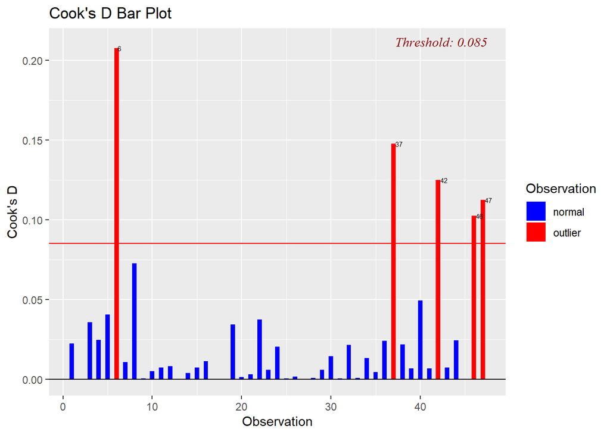

```r
library(datasets)
library(ggplot2)
library(olsrr)
data(swiss)
fit <-lm(Fertility~.,data=swiss)
#Cook’s D Bar Plot
ols_plot_cooksd_bar(fit)
```

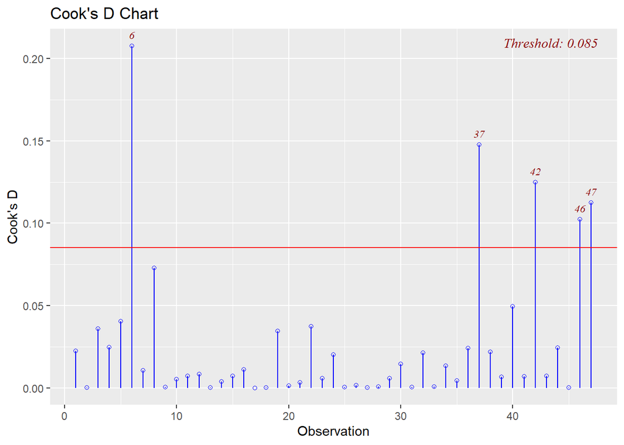

```r
#Cook’s D Chart
ols_plot_cooksd_chart(fit)
```

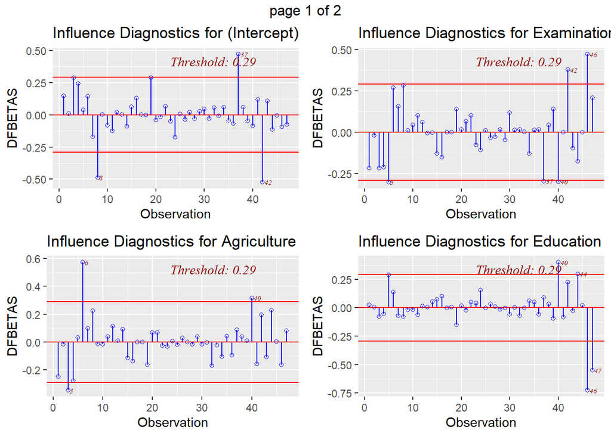

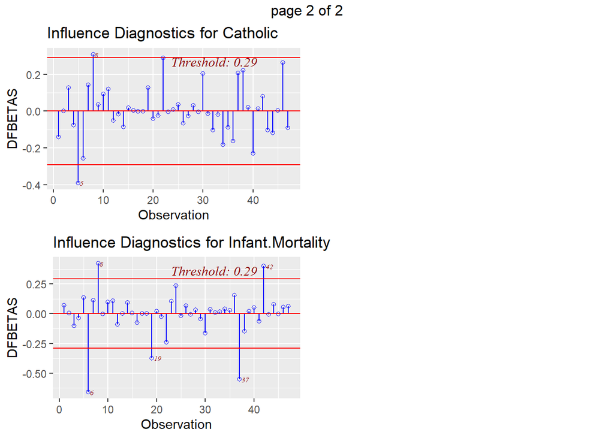

```r
#dfbetas panel;
ols_plot_dfbetas(fit)
```

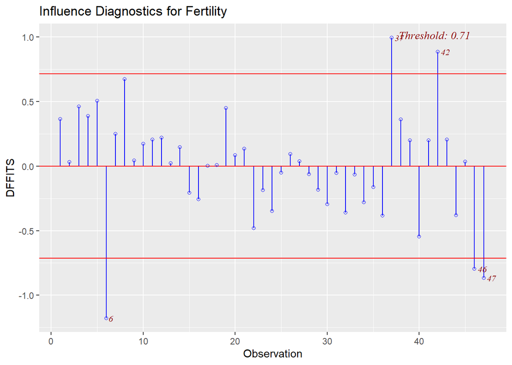

```r
#plot dffits
ols_plot_dffits(fit)
```